# Homework 3

Jan Skalski

2023-03-27

## Wstęp

Przeprowadzony przeze mnie eksperyment polegał na sprawdzeniu jak odbierane i czytelne są dwa typy wykresów: **box plot** i **violin plot**. Wykresy opierają się na zbiorze danych *serialeIMDB* z paczki danych *PogromcyDanych* i dotyczą rozkładu ocen dla poszczególnych odcinków z 10 serialów z największą łaczną liczbą głosów.

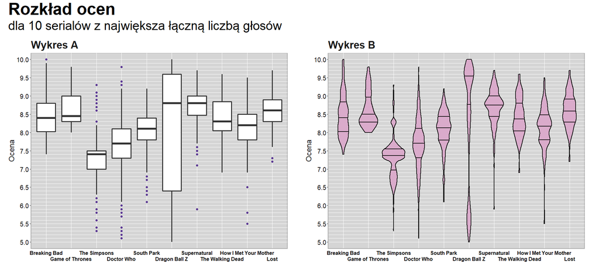

## Ankieta

Przeprowadzona na 16 osobach ankieta zawierała zestaw pytań dotyczących różnych cech rozkładu. Jako pierwsze zostały postawione pytania, na które należało odpowiedzieć na podstawie wykresu **violin plot** (Wykres B). Ta kolejność nie była przypadkowa, gdyż podejrzewałem, że ten typ wykresu okaże się trudniejszym do odczytywania, zatem chciałem by odpowiedzi były jak najbardziej wiarygodne i nie opierały się na drugim typie wykresu. Na każde pytanie była jedna poprawna odpowiedź, dla niektórych pytań dla ułatwienia była ona podawana jako wąski zakres wartości. Dla wykresu **box plot** zostały postawione te same pytania.

### Pytania

1. Ile wynosi najmniejsza ocena odcinka dla serialu “Breaking Bad”?
2. Jaka jest mediana ocen serialu “The Simpsons”?
3. Który serial ma najmniejszy rozstęp międzykwartylowy (IQR) ocen?
4. Dla którego serialu mediana ocen jest największa?
5. Który serial był najgorzej oceniony pod względem średniej arytmetycznej ocen?

Na koniec zostało postawione pytanie podsumowujące:

Który z wykresów jest dla ciebie bardziej czytelny i w razie potrzeby użył byś go do wizualizacji danych?

## Wyniki

Wyniki ankiety prezentują się następująco:

|  | Pytanie 1 | Pytanie 2 | Pytanie 3 | Pytanie 4 | Pytanie 5 |
| --- | --- | --- | --- | --- | --- |
| violin plot | 0.8125 | 0.625 | 0.5625 | 0.75 | 0.5 |
| box plot | 0.9375 | 0.8125 | 0.6875 | 0.8125 | 0.875 |

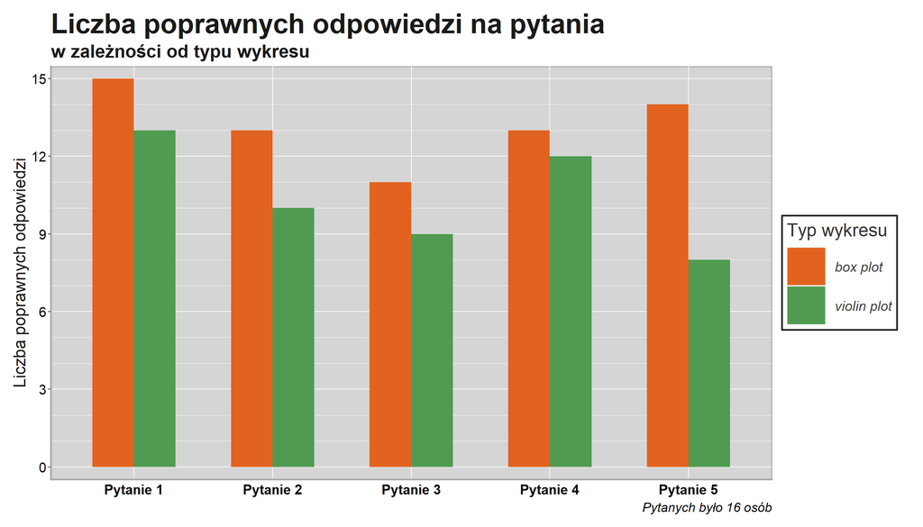

W ostatnim pytaniu dotyczącym preferencji ankietowanych wykres typu **box plot** wskazało aż 14 osób, jedynie przy 2 głosach na wykres **violin plot**.

## Podsumowanie i wnioski

Wyniki ankiety jednoznacznie wskazują, że bardziej czytelny i zrozumiały okazał się wykres A, czyli **box plot** ,mimo że informacje potrzebne do poprawnej odpowiedzi zawarte były w obu wykresach. Co ciekawe zdecydowana większość wybrałaby właśnie ten typ wykresu, chociaż **violin plot** wskazuje także na rozkład prawdopodobieństwa danej zmiennej, czego nie da się odczytać z wykresu **box plot**. Ankieta potwierdziła zatem moje przypuszczenia, że w ogólnym przypadku mniej znany typ wykresu zawierający te same cechy jest nie do końca zrozumiały i intuicyjny w odbiorze.